# Regressão Linear

### Cálculo Manuel do Erro

```python
previsoes = regressor.predict(X_teste)

resultado = abs(y_teste - previsoes)
print("Quantidade de que vai errar na média:", resultado.mean())
```

```
Quantidade de que vai errar na média: 172604.1288999542
```

### Cálculo do erro pelo sklearn

```python
from sklearn.metrics import mean_absolute_error, mean_squared_error
mae = mean_absolute_error(y_teste, previsoes)
print("MAE - Mean Absolute Error ==>", mae)
mse = mean_squared_error(y_teste, previsoes)
print("MSE - MeanSquareError ==>", mse)
```

```
MAE - Mean Absolute Error ==> 172604.1288999542
MSE - MeanSquareError ==> 70170013932.1159
```

### Qual dos erros escolher?

Usamos o MSE para ser critério para o treinamento

E usamos MAE para avaliaççao

### Gráfico do regressor

```
0.4888992901945303
```

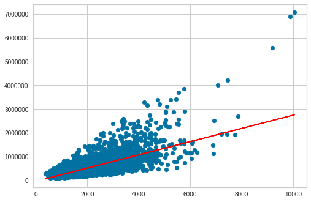

```python
plt.scatter(X_teste, y_teste)
plt.plot(X_teste, regressor.predict(X_teste), color = 'red')

regressor.score(X_teste, y_teste)
```

### Gráfico do `yellowbrick`

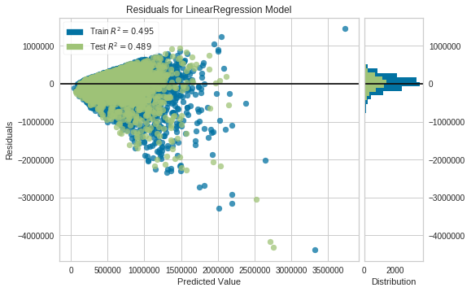

```python
from yellowbrick.regressor import ResidualsPlot

visualizer = ResidualsPlot(regressor)
visualizer.fit(X_treinamento, y_treinamento)
visualizer.score(X_teste, y_teste)
visualizer.show()
```

# Regressão Linear Múltipla

ATENÇÃO:

- No Código, a diferença entre a Regressão Linear Simples e a Regressão Linear Múltipla é a **quantidade de variáveis nas features**
  - Na Regressão Linear Simples, usamos somente uma única variável
  - Na Regressâo Linear Múltipla, usamso várias variáveis

## PreProcessamento

```python
base = pd.read_csv(file_path + 'house-prices.csv')

# A diferença entre os códigos está na quantidade de features
X = base.iloc[:, 3:19].values
print("Quantidade de Features", len(X[0]))
y = base.iloc[:, 2].values

from sklearn.model_selection import train_test_split
X_treinamento, X_teste, y_treinamento, y_teste = train_test_split(
    X, y, test_size = 0.3,random_state = 0)
```

```
Quantidade de Features 16
```

### Treinando Regressor Multiplo

```python
from sklearn.linear_model import LinearRegression
regressor = LinearRegression()
regressor.fit(X_treinamento, y_treinamento)
previsoes = regressor.predict(X_teste)
score = regressor.score(X_treinamento, y_treinamento)
print("Score do Treinamento =", score)
```

```
Score do Treinamento = 0.7029888085955005
```

### Testando Regressor Múltiplo

```python
score_test = regressor.score(X_teste, y_teste)
print("Score do Teste =", score_test)
```

```
Score do Teste = 0.6885414149062228
```

### Analisando Erros: MAE e MSE

```python
from sklearn.metrics import mean_absolute_error, mean_squared_error
mae = mean_absolute_error(y_teste, previsoes)
print("MAE - MeanAbsoluteError ==>", mae)
mse = mean_squared_error(y_teste, previsoes)
print("MSE - MeanSquareError   ==>", mse)
mae = mean_absolute_error(y_teste, previsoes)
```

```
MAE - MeanAbsoluteError ==> 123888.44377484432
MSE - MeanSquareError   ==> 42760757001.54226
```

### Plotando Gráficos

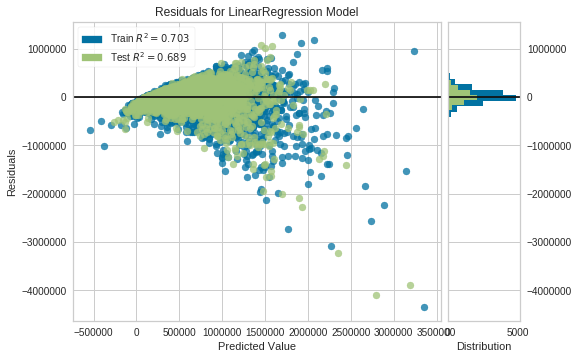

```python
from yellowbrick.regressor import ResidualsPlot
visualizer = ResidualsPlot(regressor)
visualizer.fit(X_treinamento, y_treinamento)
visualizer.score(X_teste, y_teste)
visualizer.show()
```

## Regressão Linear Simples English ML-AZ

```python
# Importing the dataset
dataset = pd.read_csv(file_path + 'Salary_Data.csv')
X = dataset.iloc[:, :-1].values
y = dataset.iloc[:, 1].values

# Splitting the dataset into the Training set and Test set
from sklearn.model_selection import train_test_split
X_train, X_test, y_train, y_test = train_test_split(X, y, test_size = 1/3, random_state = 0)
```

```python
# Fitting Simple Linear Regression to the Training set
from sklearn.linear_model import LinearRegression
regressor = LinearRegression()
regressor.fit(X_train, y_train)
```

```
LinearRegression(copy_X=True, fit_intercept=True, n_jobs=None, normalize=False)
```

```python
# Predicting the Test set results
y_pred = regressor.predict(X_test)
```

```python
# Score of Train and Test
score = regressor.score(X_train, y_train)
print("Train Score", score)

score = regressor.score(X_test, y_test)
print("Test Score", score)

# Erros of Test
from sklearn.metrics import mean_absolute_error, mean_squared_error
mae = mean_absolute_error(y_test, y_pred)
print("MAE - MeanAbsoluteError ==>", mae)
mse = mean_squared_error(y_teste, previsoes)
print("MSE - MeanSquareError   ==>", mse)
```

```
Train Score 0.9381900012894278
Test Score 0.9749154407708353
MAE - MeanAbsoluteError ==> 3426.42693743071
MSE - MeanSquareError ==> 42760757001.54226
```

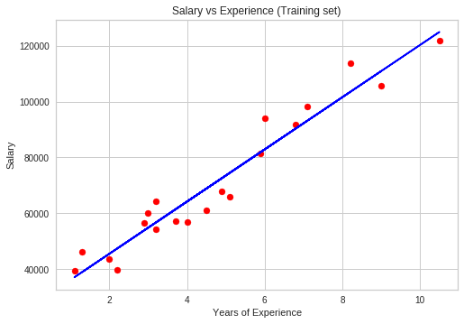

```python
# Visualising the Training set results
plt.scatter(X_train, y_train, color = 'red')
plt.plot(X_train, regressor.predict(X_train), color = 'blue')
plt.title('Salary vs Experience (Training set)')
plt.xlabel('Years of Experience')
plt.ylabel('Salary')
plt.show()
```

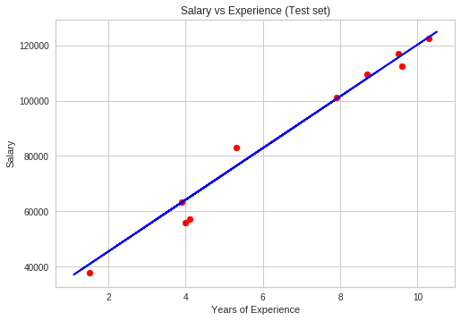

```python
# Visualising the Test set results
plt.scatter(X_test, y_test, color = 'red')
plt.plot(X_train, regressor.predict(X_train), color = 'blue')
plt.title('Salary vs Experience (Test set)')
plt.xlabel('Years of Experience')
plt.ylabel('Salary')
plt.show()
```

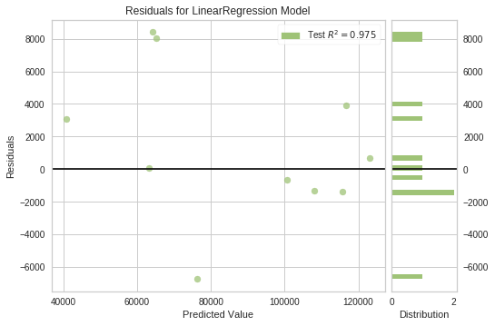

```python
# Gráfico do YellowBrick
from yellowbrick.regressor import ResidualsPlot
visualizer = ResidualsPlot(regressor)
visualizer.score(X_test, y_test)
visualizer.show()
```

## Questions Simple Linear Regression

### Simple Linear Regression Intuition

What are exactly the coefficients b 0 and b 1 in the Simple Linear Regression equation: ’Salary = b 0 + b 1 × Experience?

b 0 is the salary you get with no experience and b 1 is the increase in salary per year.

Why do we take the squared differences and simply not the absolute differences?

Because the squared differences makes it easier to derive a regression line. Indeed, to find that line we need to compute the first derivative of the loss error function, and it is much harder to compute the derivative of absolute values than squared values.

### Simple Linear Regression in Python

Why didn’t we apply Feature Scaling in our Simple Linear Regression model?

It’s simply because since y is a linear combination of the independent variables, the coefficients can adapt their scale to put everything on the same scale. For example if you have two independent variables x 1 and x 2 and if y takes values between 0 and 1, x 1 takes values between 1 and 10 and x 2 takes values between 10 and 100, then b 1 can be multiplied by 0.1 and b 2 can be multiplied by 0.01 so that y, b 1 x 1 and b 2 x 2 are all on the same scale.

What does ’regressor.fit(X_train, y_train)’ do exactly?

The fit method will take the values of X_train and y_train and then will compute the coefficients b 0 and b 1 of the Simple Linear Regression equation (y = b 0 + b 1 x) as seen in the Intuition Lecture. That’s the whole purpose of this fit method here.

## Multiple Regression English A-Z

Deu uns problemas com `OneHotCoder`, por isso eu não fiz.

Mas da mesma forma, só muda que na Múltipla o fato de ter mais `features`

## Questions Multiple Linear Regression

### Multiple Linear Regression Intuition

What are the Multiple Linear Regression assumptions in more details?

- Linearity: There must be a linear relationship between the dependent variable and the independent variables. Scatterplots can show whether there is a linear or curvilinear relationship.
- Homoscedasticity: This assumption states that the variance of error terms is similar across the values of the independent variables. A plot of standardized residuals versus predicted values can show whether points are equally distributed across all values of the independent variables.
- Multivariate Normality: Multiple Linear Regression assumes that the residuals (the differences between the observed value of the dependent variable y and the predicted value ŷ are normally distributed. Independence of errors: Multiple Linear Regression assumes that the residuals (the differences between the observed value of the dependent variable y and the predicted value ŷ are independent.
- Lack of multicollinearity: Multiple Linear Regression assumes that the independent variables are not highly correlated with each other. This assumption is tested using Variance Inflation Factor (VIF) values.

How is the coefficient b 0 related to the dummy variable trap?

```
Since D 2 = 1 − D 1 then if you include both D 1 and D 2 you get:
y = b 0 + b 1 x 1 + b 2 x 2 + b 3 x 3 + b 4 D 1 + b 5 D 2
= b 0 + b 1 x 1 + b 2 x 2 + b 3 x 3 + b 4 D 1 + b 5 (1 − D 1 )
= b 0 + b 5 + b 1 x 1 + b 2 x 2 + b 3 x 3 + (b 4 − b 5 )D 1
= b ∗ 0 + b 1 x 1 + b 2 x 2 + b 3 x 3 + b ∗ 4 D 1
with b ∗ 0 = b 0 + b 5 and b ∗ 4 = b 4 − b 5
```

Therefore the information of the redundant dummy variable D 2 is going into the constant b 0 .